# Computational Statistical Methods_Assignment_Plan and EDA

W06G03

2026-04-19

# Introduction of the Project:

## 1. Framing and Dataset Selection:

### 1.1 Problem Statement:

In urban planning and public safety, identifying the underlying drivers of criminal activity is essential for efficient resource allocation. While traditional crime reporting provides a historical log of “where” and “when” incidents occur, it often lacks the socio-economic context required to understand “why” certain areas are more vulnerable than others. This project addresses the challenge of predicting specific criminal offence subtypes in South Australia by analyzing the intersection of temporal patterns and socio-economic disadvantage.

### 1.2. Research Question

To what extent do temporal (calendar and holiday structure), spatial (suburb proximity), and socio-economic (SEIFA 2021 deciles) features improve the conditional prediction of Level 3 offence subtypes given Level 1 and Level 2 offence categories?

### 1.3.Motivation and Impact

Criminal activity affects a diverse range of stakeholders, from local residents and business owners to law enforcement and policy makers.

#### For Law Enforcement:

Accurate identification of high-risk areas allows for “intelligence-led policing,” ensuring patrols are stationed where they are most needed during high-risk periods (e.g., long weekends or school holidays).

#### For Policy Makers:

Understanding the correlation between SEIFA ranks (economic resources and employment) and specific crime types helps in designing long-term social interventions rather than just short-term policing.

#### For the Community:

Improved predictive accuracy helps individuals and community groups make informed decisions regarding neighborhood watch programs and personal safety measures.

## 2. Consider & Gather Data

### 2.1 Data Sources

**Primary Dataset**: South Australia Police (SAPOL) - 2024-25 Crime Statistics. This dataset provides granular incident data, including dates, suburbs, and a three-level hierarchy of offence descriptions.

Source:https://data.sa.gov.au/data/dataset/crime-statistics/resource/4a553fc6-71fe-4dac-8096-c29abc269c76

#### 2.1.1 Outcome from the primary dataset:

##### ii)Weak Feature-Target Relationship:

Predicting 28 specific offence subtypes (Level 3) requires understanding the environment. Basic crime logs do not capture variables like unemployment rates or economic resources, which are proven drivers of criminal behavior.

##### iii)Low Complexity:

Relying only on the primary dataset would fail the “Complex” requirement of this project.

To overcome these limitations, we chose to integrate the ABS SEIFA 2021 Enrichment Dataset which is ABS Socio-Economic Indexes for Areas (SEIFA) 2021. This provides standardized rankings of Australian areas based on relative socio-economic advantage and disadvantage.

Source:https://www.abs.gov.au/statistics/people/people-and-communities/socio-economic-indexes-areas-seifa-australia/2021#data-downloads

#### 2.1.2 Data Linkage and Integration

To transform these sources into a integrated dataset, we performed the following steps:

**Step 1:** Filtering: We identified that the Suburb and Locality (SAL) codes for South Australia fall within the 40001 to 49999 range and filtered the ABS data accordingly.

**Step 2:** Extraction & Refinement: We targeted four specific SEIFA tables: Advantage/Disadvantage, Disadvantage, Economic Resources, and Employment, extracting the Decile Ranks for each suburb.

**Step 3:** Normalization: Suburb names in both datasets were converted to uppercase and stripped of whitespace to ensure a high-fidelity match.

**Step 4:** Linkage: We executed an inner join using salname (from SEIFA) and Suburb-Incident (from SAPOL) as the primary keys.

#### Description of Columns in Primary dataset:

[output not shown]

#### The columns integrated from SEIFA:

| Variable | Description |
| --- | --- |
| salcode | SEIFA area code used to identify the statistical area. |
| sal_adv_dis | Index of Relative Socio-economic Advantage and Disadvantage, ranked from 1 to 10, where higher values indicate greater advantage. |
| sal_dis | Index of Relative Socio-economic Disadvantage, ranked from 1 to 10, where 1 = most disadvantaged and 10 = least disadvantaged. |
| sal_Economic_Resources | Index of Economic Resources, ranked from 1 to 10, where higher values indicate stronger economic resources. |
| sal_Employment | Index of Employment and Occupation, ranked from 1 to 10, where higher values indicate better employment and occupational conditions. |

#### Addition of few more feature for high dimensional analysis:

| Variable | Description |
| --- | --- |
| Cal_Month | Calendar month extracted from the reported date. |
| Cal_DayOfMonth | Day of the month extracted from the reported date. |
| Cal_DayOfWeek | Day of week name or numeric code extracted from the reported date. |
| IsWeekend | Weekend flag, where 1 indicates weekend and 0 indicates weekday. |
| Season_SH | Southern Hemisphere season based on the reported date. |
| IsPublicHoliday_SA | Flag indicating whether the date is a South Australian public holiday. |
| IsLongWeekend | Flag for long weekend dates, including public holidays and adjacent weekend patterns. |
| IsSchoolHoliday_SA | Flag indicating whether the date falls within South Australian school holidays. |

## Requirements:

```r
library(ggplot2)
library(tidyr)
```

### 2.2 Dataset Justification (Requirements)

#### Loading the dataset

The integrated raw dataset, hosted on GitHub, was imported directly into the analysis using the raw CSV link.

```r
csv_link <- "https://raw.githubusercontent.com/SreeLakshmiGirisan/Computational-Statistics-_dataset/main/Final_Spatial_Crime_SEIFA.csv"
df <- read.csv(csv_link)
```

#### 2.2.1. Large Size (>10,000 observations)

```r
dim(df)
```

```
## [1] 76598    20
```

With 76,598 observations, the dataset is significantly larger.This size is beneficial for training deep ensemble models but requires efficient implementationsvto manage memory usage during cross-validation.

#### 2.2.2. Multi-class (Class Distribution & Imbalance)

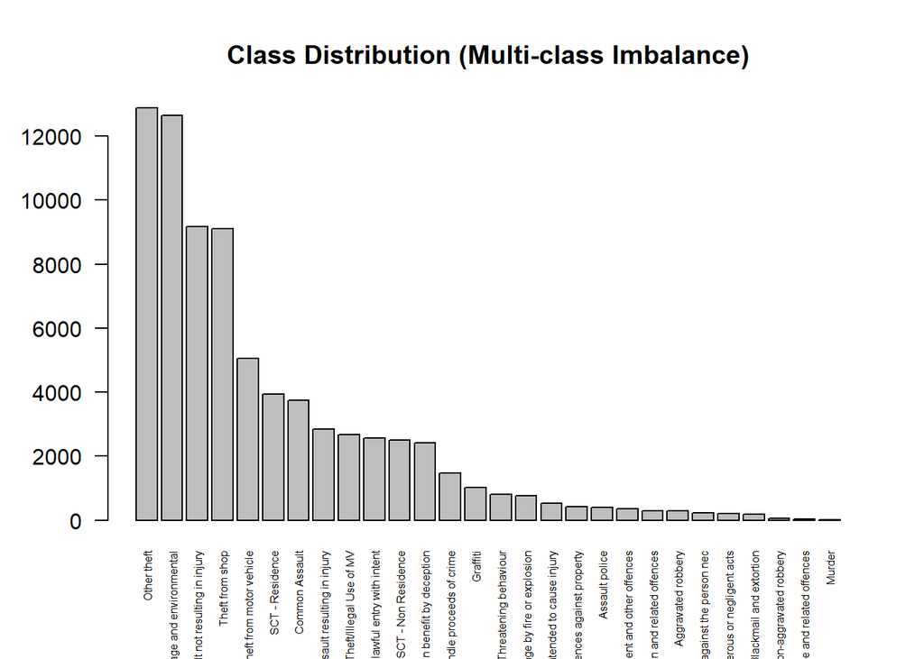

```r
# Graphical distribution
target_dist <- table(df$Offence.Level.3.Description)
barplot(sort(target_dist, decreasing = TRUE),
        las = 2, cex.names = 0.5,
        main = "Class Distribution (Multi-class Imbalance)")
```

The target variable consists of 28 unique classes, making this a Multi-class classification problem. There is severe Class Imbalance common offences like “Other Theft” have thousands of entries, while “Murder” has very few.

#### 2.2.3. Integration (Data Linkage)

```r
# Show the columns added via integration
# salcode and SEIFA ranks were not in the primary dataset
head(df[, c("salcode", "sal_dis", "sal_adv_dis","sal_Economic_Resources","sal_Employment")])
```

```
##   salcode sal_dis sal_adv_dis sal_Economic_Resources sal_Employment
## 1   40002       4           9                      1             10
## 2   40002       4           9                      1             10
## 3   40002       4           9                      1             10
## 4   40002       4           9                      1             10
## 5   40002       4           9                      1             10
## 6   40002       4           9                      1             10
```

The data linkage process involved an Inner Join. We utilized the Suburb - Incident column from the primary SAPOL dataset and the salname column from the ABS enrichment dataset as the Key. This integration provides the socio-economic context missing from the original police reports.

#### 2.2.4. Complex (Features & Dimensionality)

```r
# Show feature count and data types
str(df)
```

```
## 'data.frame':    76598 obs. of  20 variables:
##  $ Reported.Date              : chr  "2024-07-01" "2024-07-01" "2024-07-01" "2024-07-01" ...
##  $ Suburb...Incident          : chr  "ADELAIDE" "ADELAIDE" "ADELAIDE" "ADELAIDE" ...
##  $ Postcode...Incident        : int  5000 5000 5000 5000 5000 5000 5000 5000 5000 5950 ...
##  $ Offence.Level.1.Description: chr  "OFFENCES AGAINST PROPERTY" "OFFENCES AGAINST PROPERTY" "OFFENCES AGAINST PROPERTY" "OFFENCES AGAINST PROPERTY" ...
##  $ Offence.Level.2.Description: chr  "PROPERTY DAMAGE AND ENVIRONMENTAL" "SERIOUS CRIMINAL TRESPASS" "THEFT AND RELATED OFFENCES" "THEFT AND RELATED OFFENCES" ...
##  $ Offence.Level.3.Description: chr  "Other property damage and environmental" "SCT - Non Residence" "Other theft" "Theft from motor vehicle" ...
##  $ Offence.count              : int  3 1 2 1 4 1 4 4 1 1 ...
##  $ salcode                    : int  40002 40002 40002 40002 40002 40002 40002 40002 40002 40003 ...
##  $ sal_adv_dis                : num  9 9 9 9 9 9 9 9 9 NA ...
##  $ sal_dis                    : num  4 4 4 4 4 4 4 4 4 NA ...
##  $ sal_Economic_Resources     : num  1 1 1 1 1 1 1 1 1 NA ...
##  $ sal_Employment             : num  10 10 10 10 10 10 10 10 10 NA ...
##  $ Cal_Month                  : int  7 7 7 7 7 7 7 7 7 7 ...
##  $ Cal_DayOfMonth             : int  1 1 1 1 1 1 1 1 1 1 ...
##  $ Cal_DayOfWeek              : chr  "Monday" "Monday" "Monday" "Monday" ...
##  $ IsWeekend                  : int  0 0 0 0 0 0 0 0 0 0 ...
##  $ Season_SH                  : chr  "Winter" "Winter" "Winter" "Winter" ...
##  $ IsPublicHoliday_SA         : int  0 0 0 0 0 0 0 0 0 0 ...
##  $ IsLongWeekend              : int  0 0 0 0 0 0 0 0 0 0 ...
##  $ IsSchoolHoliday_SA         : int  0 0 0 0 0 0 0 0 0 0 ...
```

```r
# Numerical summary to show mix of continuous and categorical
summary(df)
```

```
##  Reported.Date      Suburb...Incident  Postcode...Incident
##  Length:76598       Length:76598       Min.   : 872
##  Class :character   Class :character   1st Qu.:5042
##  Mode  :character   Mode  :character   Median :5108
##                                        Mean   :5145
##                                        3rd Qu.:5169
##                                        Max.   :5950
##
##  Offence.Level.1.Description Offence.Level.2.Description
##  Length:76598                Length:76598
##  Class :character            Class :character
##  Mode  :character            Mode  :character
##
##
##
##
##  Offence.Level.3.Description Offence.count       salcode       sal_adv_dis
##  Length:76598                Min.   : 1.000   Min.   :40001   Min.   : 1.000
##  Class :character            1st Qu.: 1.000   1st Qu.:40404   1st Qu.: 1.000
##  Mode  :character            Median : 1.000   Median :40899   Median : 3.000
##                              Mean   : 1.234   Mean   :40827   Mean   : 3.975
##                              3rd Qu.: 1.000   3rd Qu.:41201   3rd Qu.: 7.000
##                              Max.   :19.000   Max.   :41695   Max.   :10.000
##                                                               NA's   :873
##     sal_dis       sal_Economic_Resources sal_Employment     Cal_Month
##  Min.   : 1.000   Min.   : 1.000         Min.   : 1.000   Min.   : 1.00
##  1st Qu.: 1.000   1st Qu.: 1.000         1st Qu.: 1.000   1st Qu.: 3.00
##  Median : 2.000   Median : 2.000         Median : 3.000   Median : 7.00
##  Mean   : 3.494   Mean   : 2.518         Mean   : 4.436   Mean   : 6.53
##  3rd Qu.: 5.000   3rd Qu.: 3.000         3rd Qu.: 8.000   3rd Qu.:10.00
##  Max.   :10.000   Max.   :10.000         Max.   :10.000   Max.   :12.00
##  NA's   :873      NA's   :873            NA's   :744
##  Cal_DayOfMonth  Cal_DayOfWeek        IsWeekend       Season_SH
##  Min.   : 1.00   Length:76598       Min.   :0.0000   Length:76598
##  1st Qu.: 8.00   Class :character   1st Qu.:0.0000   Class :character
##  Median :16.00   Mode  :character   Median :0.0000   Mode  :character
##  Mean   :15.72                      Mean   :0.2557
##  3rd Qu.:23.00                      3rd Qu.:1.0000
##  Max.   :31.00                      Max.   :1.0000
##
##  IsPublicHoliday_SA IsLongWeekend     IsSchoolHoliday_SA
##  Min.   :0.00000    Min.   :0.00000   Min.   :0.0000
##  1st Qu.:0.00000    1st Qu.:0.00000   1st Qu.:0.0000
##  Median :0.00000    Median :0.00000   Median :0.0000
##  Mean   :0.02734    Mean   :0.01627   Mean   :0.2461
##  3rd Qu.:0.00000    3rd Qu.:0.00000   3rd Qu.:0.0000
##  Max.   :1.00000    Max.   :1.00000   Max.   :1.0000
##
```

The data is Complex because it contains a mix of categorical predictors (Suburb, Offence Levels) and continuous SEIFA ranks.

#### 2.2.5 Messy (Missingness)

```r
library(visdat)
library(patchwork)
```

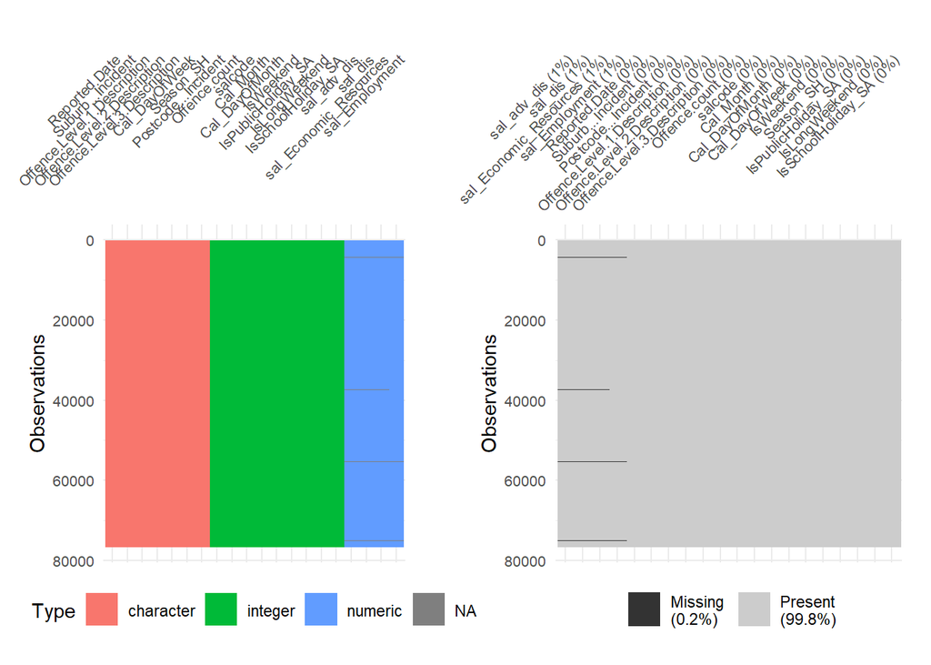

```r
p1 <- vis_dat(df, warn_large_data = FALSE) +
  theme(
    axis.text.x = element_text(angle = 45, hjust = 1, size = 8),
    axis.text.y = element_text(size = 8),
    legend.position = "bottom",
    plot.title = element_text(face = "bold"),
    plot.margin = margin(10, 10, 10, 10)
  )

p2 <- vis_miss(df, warn_large_data = FALSE, sort_miss = TRUE) +
  theme(
    axis.text.x = element_text(angle = 45, hjust = 1, size = 8),
    axis.text.y = element_text(size = 8),
    legend.position = "bottom",
    plot.title = element_text(face = "bold"),
    plot.margin = margin(10, 10, 10, 10)
  )

(p1 | plot_spacer() | p2) + plot_layout(widths = c(1, 0.06, 1.15))
```

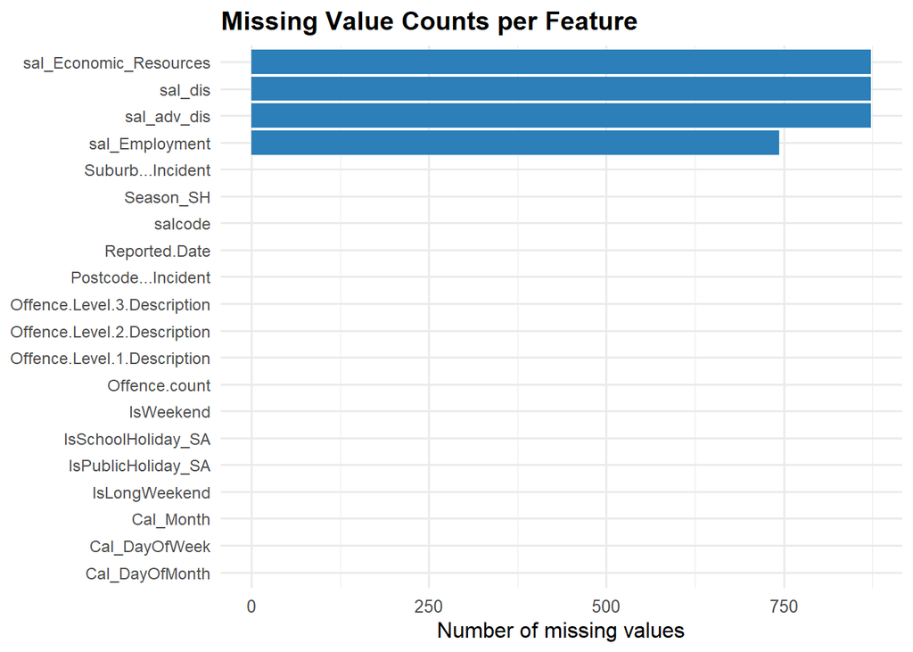

```r
library(ggplot2)

miss_df <- data.frame(
  variable = names(df),
  missing = sapply(df, function(x) sum(is.na(x)))
)

miss_df <- miss_df[order(miss_df$missing, decreasing = TRUE), ]

ggplot(miss_df, aes(x = reorder(variable, missing), y = missing)) +
  geom_col(fill = "#2C7FB8") +
  coord_flip() +
  labs(
    title = "Missing Value Counts per Feature",
    x = NULL,
    y = "Number of missing values"
  ) +
  theme_minimal(base_size = 12) +
  theme(
    plot.title = element_text(face = "bold"),
    axis.text.y = element_text(size = 9)
  )
```

The vis_miss plot reveals that missingness is concentrated in the SEIFA indices.Must determine if this is Missing At Random (MAR); in this case, the 873 missing values likely correspond to low-population suburbs where the ABS suppresses data for privacy.

## 3. Exploratory Data Analysis (EDA)

### 3.1.Univariate Analysis:

To look at one variable at a time to see its shape, check for mistakes (outliers), and see if any data is missing.

#### A. Histogram and Bar plots (Numeric Distribution)

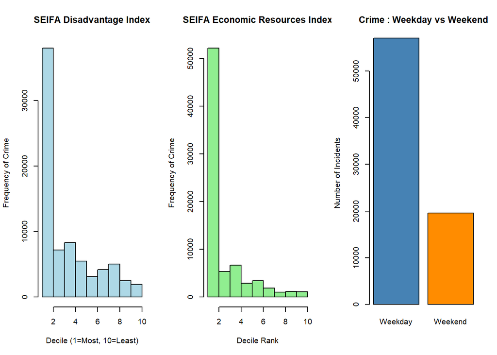

```r
# Set up a plotting area for 3 graphs (Week 1)
par(mfrow = c(1, 3))

# 1. Distribution of Disadvantage (Integrated SEIFA)
hist(df$sal_dis,
     main = "SEIFA Disadvantage Index",
     xlab = "Decile (1=Most, 10=Least)",
     ylab = "Frequency of Crime",
     col = "lightblue",
     breaks = 10)

# 2. Distribution of Economic Resources (Integrated SEIFA)
hist(df$sal_Economic_Resources,
     main = "SEIFA Economic Resources Index",
     xlab = "Decile Rank",
     ylab = "Frequency of Crime",
     col = "lightgreen",
     breaks = 10)
# 3. Showing the count of incidents by part of the week
# 1. Frequency Table
# 0 = Weekday, 1 = Weekend

barplot(table(df$IsWeekend),
        main = "Crime : Weekday vs Weekend",
        names.arg = c("Weekday", "Weekend"),
        col = c("steelblue", "darkorange"),
        ylab = "Number of Incidents")
```

#### Insights from these plots:

**SEIFA Disadvantage Index Graph**: This variable is Right-Skewed (positively skewed).The “tail” of the data stretching toward the higher deciles (the right side), Which means Most of crime incidents are concentrated in suburbs with lower decile ranks, which represent higher disadvantage. There are very few incidents in the “wealthier” decile 10 suburbs.

**Crime- Weekday vs Weekend Graph**: Using the bar plot method, the distribution of incidents across the weekly cycle. While the raw frequency is higher on weekdays than the weekends, this temporal feature serves as a critical ‘prior’ for our models, as the density of specific incident subtypes may shift significantly during the weekend period.

By comparing the plots, we can visually assess the socio-economic and temporal spread of the crime incidents.These plots act as basic density estimators, revealing whether specific socio-economic ‘strata’ and the temporal spread are over-represented in the SAPOL incident logs.

#### B. Missing Values

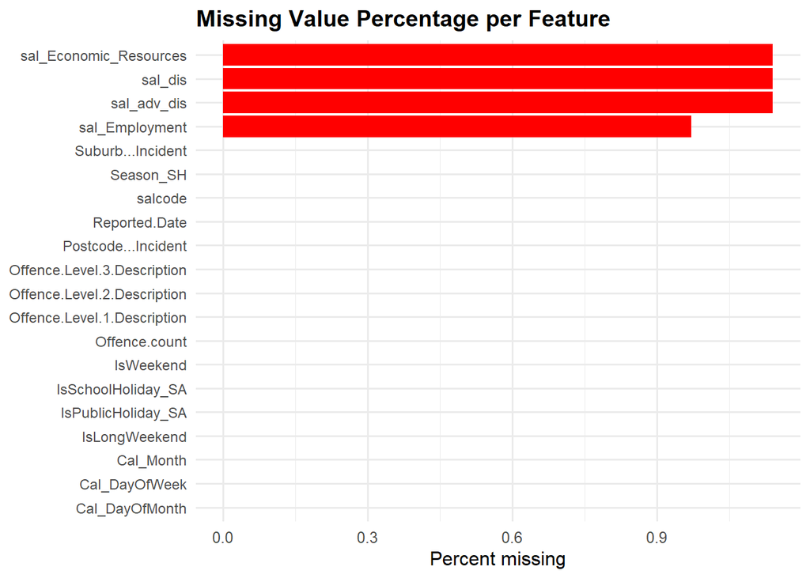

```r
library(ggplot2)

miss_df <- data.frame(
  variable = names(df),
  missing_pct = sapply(df, function(x) mean(is.na(x)) * 100)
)

miss_df <- miss_df[order(miss_df$missing_pct, decreasing = TRUE), ]

ggplot(miss_df, aes(x = reorder(variable, missing_pct), y = missing_pct)) +
  geom_col(fill = "red") +
  coord_flip() +
  labs(
    title = "Missing Value Percentage per Feature",
    x = NULL,
    y = "Percent missing"
  ) +
  theme_minimal(base_size = 12) +
  theme(
    plot.title = element_text(face = "bold"),
    axis.text.y = element_text(size = 9)
  )
```

```r
colSums(is.na(df))
```

```
##               Reported.Date           Suburb...Incident
##                           0                           0
##         Postcode...Incident Offence.Level.1.Description
##                           0                           0
## Offence.Level.2.Description Offence.Level.3.Description
##                           0                           0
##               Offence.count                     salcode
##                           0                           0
##                 sal_adv_dis                     sal_dis
##                         873                         873
##      sal_Economic_Resources              sal_Employment
##                         873                         744
##                   Cal_Month              Cal_DayOfMonth
##                           0                           0
##               Cal_DayOfWeek                   IsWeekend
##                           0                           0
##                   Season_SH          IsPublicHoliday_SA
##                           0                           0
##               IsLongWeekend          IsSchoolHoliday_SA
##                           0                           0
```

#### Insights:

Reason for Missing values:

#### C.Outliers:

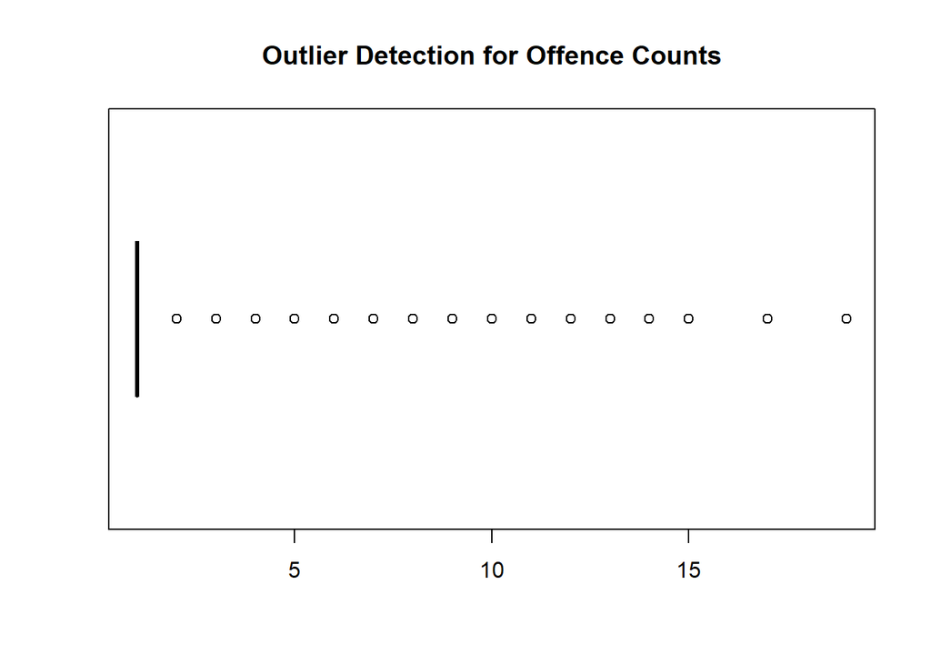

```r
boxplot(df$Offence.count,
        main = "Outlier Detection for Offence Counts",
        col = "salmon",
        horizontal = TRUE)
```

### 3.2. Bivariate Analysis:

This analysis is on relationships between features and features or relationships between features and outcome variables.

#### i) SEIFA features with Level 1 offences:

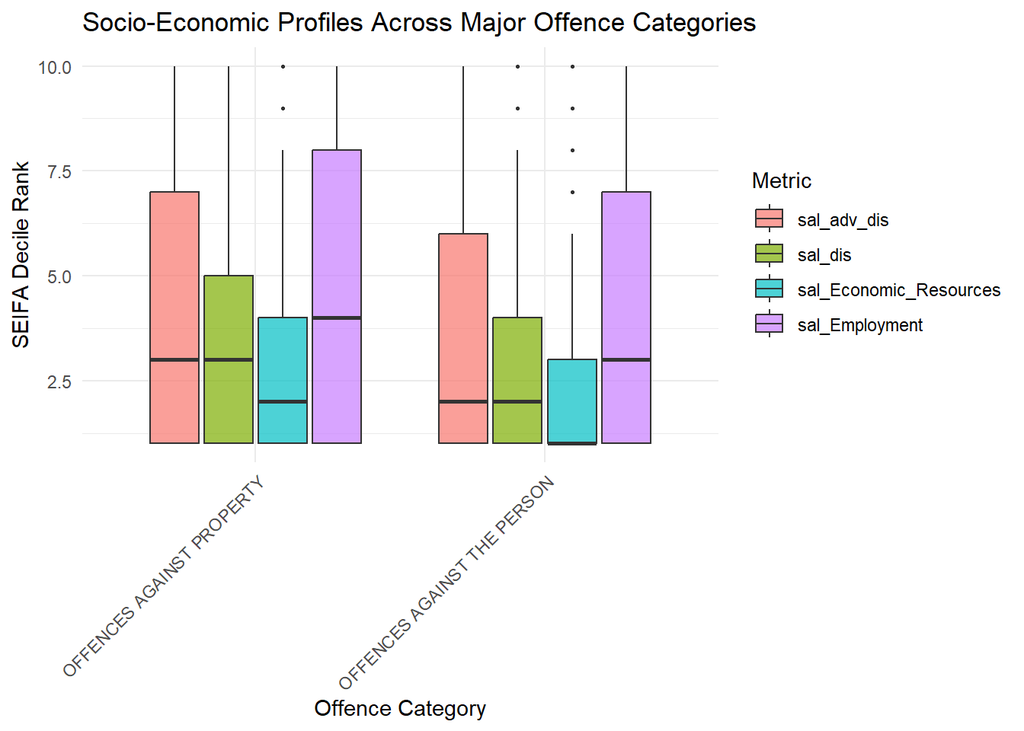

```r
# Reshaping the data for a single visualization
df_long <- df %>%
  pivot_longer(cols = c(sal_dis, sal_adv_dis, sal_Economic_Resources, sal_Employment),
               names_to = "SEIFA_Metric",
               values_to = "Decile_Rank")

# Single Plot: SEIFA Distributions by Crime Type
ggplot(df_long, aes(x = Offence.Level.1.Description, y = Decile_Rank, fill = SEIFA_Metric)) +
  geom_boxplot(outlier.size = 0.5, alpha = 0.7) +
  theme_minimal() +
  labs(title = "Socio-Economic Profiles Across Major Offence Categories",
       x = "Offence Category",
       y = "SEIFA Decile Rank",
       fill = "Metric") +
  theme(axis.text.x = element_text(angle = 45, hjust = 1))
```

#### ii) Grouped Bar Plot: Check if certain crimes are more likely on the Weekend vs. Weekdays.

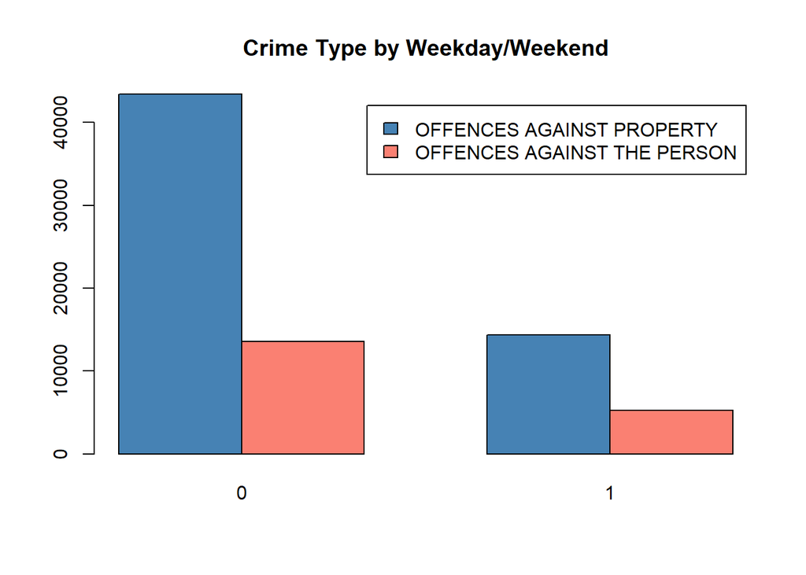

```r
# Relationship between Part of Week and Offence Level 1
counts <- table(df$Offence.Level.1.Description, df$IsWeekend)
barplot(counts, main = "Crime Type by Weekday/Weekend",
        col = c("steelblue", "salmon"),
        legend = rownames(counts), beside = TRUE)
```

#### Insights:

The grouped bar plot reveals that the frequency of both major crime categories is higher on weekdays (0) than on weekends (1). This primary trend is a reflection of the 5:2 ratio of the calendar week; however, the relative proportions provide a deeper insight into temporal crime density. Specifically, the “Offences Against Property” category maintains a dominant lead over “Offences Against the Person” across both periods. As discussed in the context of classification, this consistency suggests that while the total volume of reports decreases during the weekend, the underlying distribution of offence types remains relatively stable. These “prior probabilities” are essential for our model to understand that the day of the week acts as a volume regulator rather than a fundamental shift in the type of crime likely to be encountered in a given suburb.

[figure not shown]

```r
#Locally weighted scatter plot smoothing
library(ggplot2)
ggplot(df, aes(x = sal_dis, y = Offence.count)) +
  geom_jitter(alpha = 0.1) + # Jitter helps see overlapping points
  geom_smooth(method = "loess", span = 0.7) +
  labs(title = "Trend: SEIFA Rank vs. Offence Count")
```

### 3.3. Data Visualization: Analyzing the data using Additional graphs/tables with insights

#### 3.3.1. Seasonal Distribution of Crime

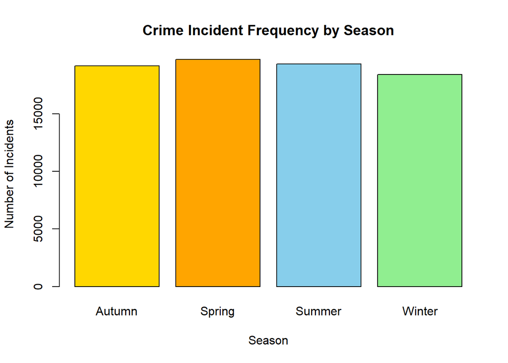

```r
# Frequency Bar Plot for Seasons
# Checking if crime peaks in specific seasons
season_counts <- table(df$Season_SH)
barplot(season_counts,
        main = "Crime Incident Frequency by Season",
        col = c("gold", "orange", "skyblue", "lightgreen"),
        ylab = "Number of Incidents",
        xlab = "Season")
```

#### 3.3.2 Long Weekend vs. Regular Days

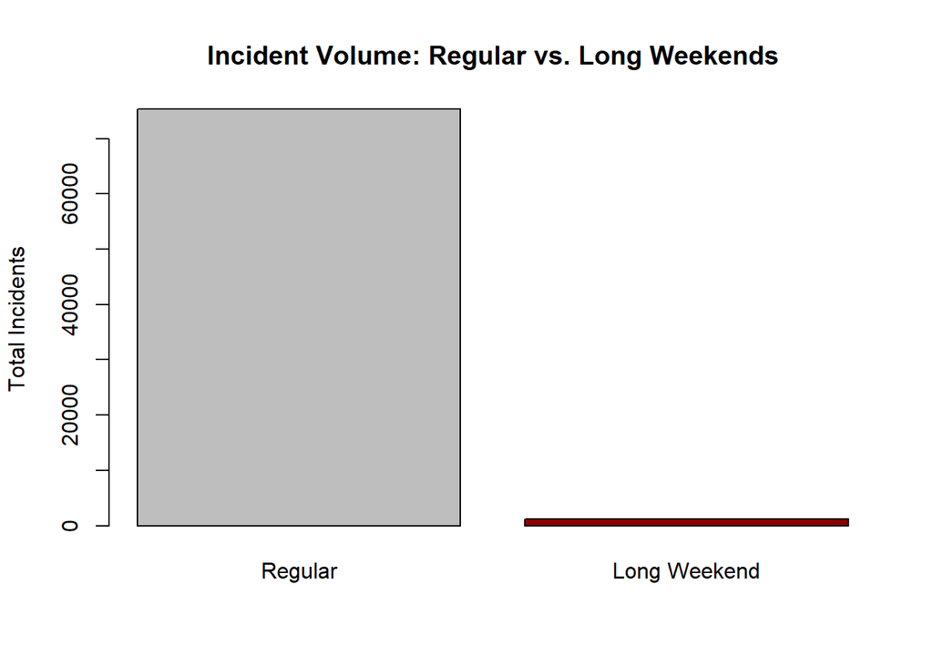

```r
# Comparison of Long Weekends (Week 1)
# 0 = Regular Day/Weekend, 1 = Long Weekend
long_weekend_counts <- table(df$IsLongWeekend)
barplot(long_weekend_counts,
        main = "Incident Volume: Regular vs. Long Weekends",
        names.arg = c("Regular", "Long Weekend"),
        col = c("grey", "darkred"),
        ylab = "Total Incidents")
```

#### 3.3.3 School Holiday Impact

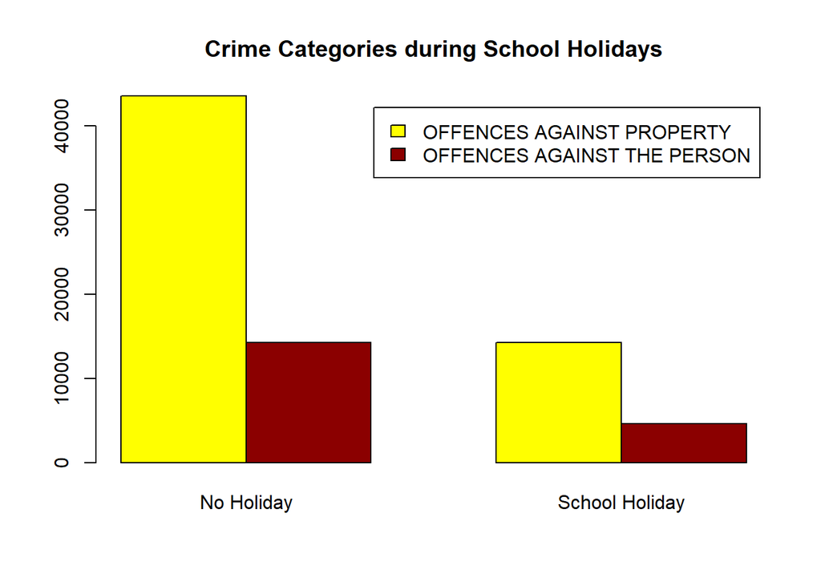

```r
# Grouped Bar Plot: Crime Type vs School Holidays
# 0 = No School Holiday, 1 = School Holiday
holiday_table <- table(df$Offence.Level.1.Description, df$IsSchoolHoliday_SA)
barplot(holiday_table,
        beside = TRUE,
        main = "Crime Categories during School Holidays",
        col = c("yellow", "darkred"),
        legend = rownames(holiday_table),
        names.arg = c("No Holiday", "School Holiday"))
```

#### Insights :

The additional temporal visualizations demonstrate that crime in South Australia is not static but fluctuates according to the calendar. By analyzing Seasons, Long Weekends, and School Holidays, we have identified specific periods where incident volumes shift.These categorical temporal features, when combined with our integrated socio-economic data, create a multi-layered ‘profile’ for each incident, significantly improving the model’s ability to predict high-risk scenarios.

#### 3.3.4 PCA (Principal Component Analysis)

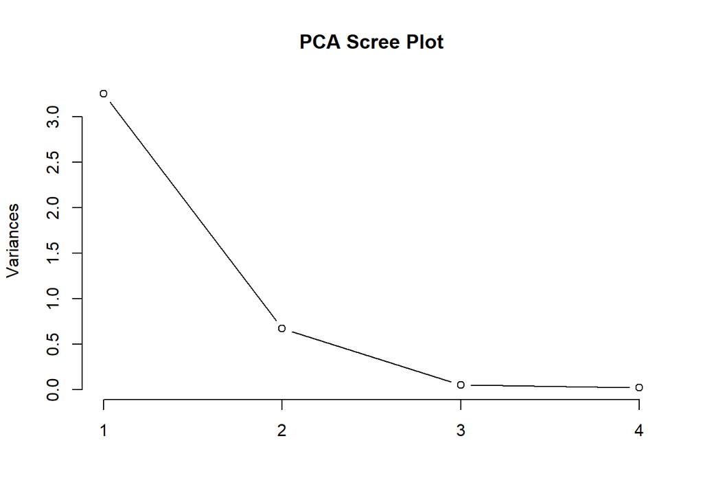

```r
# PCA for Dimensionality Reduction
seifa_vars <- na.omit(df[, c("sal_adv_dis", "sal_dis", "sal_Economic_Resources", "sal_Employment")])
pca_res <- prcomp(seifa_vars, scale. = TRUE)

# Scree Plot
plot(pca_res, type = "l", main = "PCA Scree Plot")
```

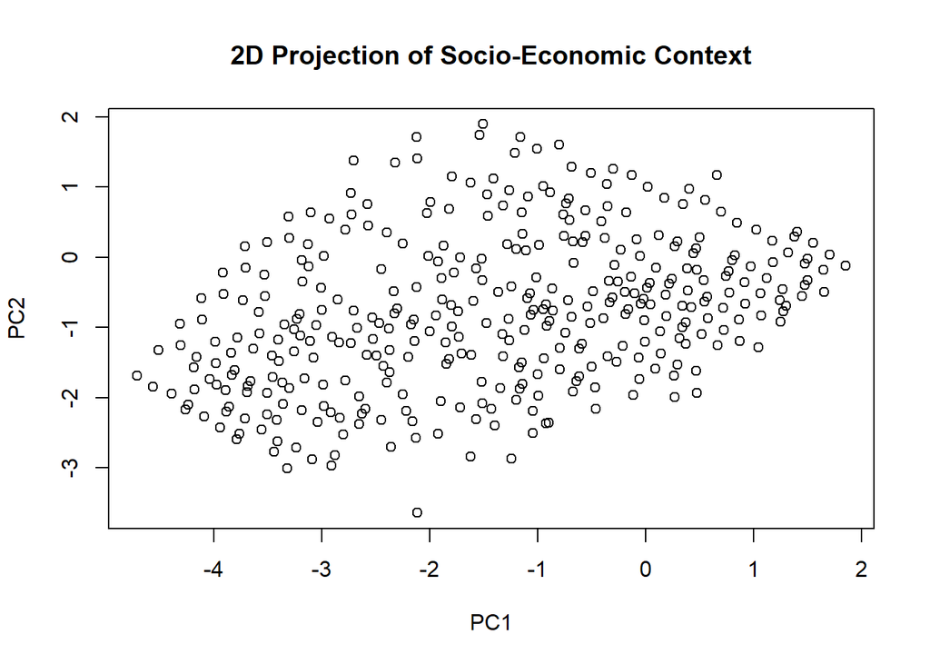

```r
# PCA 2D Scores Plot
plot(pca_res$x[,1], pca_res$x[,2], xlab="PC1", ylab="PC2", main="2D Projection of Socio-Economic Context")
```

#### Insight:

The scree plot shows a strong decline after the first component, indicating that most of the variance in the SEIFA variables is explained by PC1. The second component adds limited additional information, while the last two components contribute very little. The 2D PCA projection shows a broad elongated pattern, suggesting the SEIFA indices are correlated and can be summarized using fewer components.

#### 3.3.5 Pearson Correlation Matrix:

```r
cols <- c("Offence.Count", "sal_adv_dis", "sal_dis",
          "sal_Economic_Resources", "sal_Employment")

setdiff(cols, names(df))
```

```
## [1] "Offence.Count"
```

```r
vars <- df[, intersect(cols, names(df))]
cor_matrix <- cor(vars, use = "complete.obs")
round(cor_matrix, 2)
```

```
##                        sal_adv_dis sal_dis sal_Economic_Resources
## sal_adv_dis                   1.00    0.91                   0.59
## sal_dis                       0.91    1.00                   0.81
## sal_Economic_Resources        0.59    0.81                   1.00
## sal_Employment                0.95    0.79                   0.41
##                        sal_Employment
## sal_adv_dis                      0.95
## sal_dis                          0.79
## sal_Economic_Resources           0.41
## sal_Employment                   1.00
```

#### Insights:

The correlation matrix shows strong positive associations among the SEIFA indices, especially between sal_adv_dis, sal_dis, and sal_Employment. This indicates that the SEIFA variables are highly related and likely capture overlapping aspects of socio-economic context.

## 4.Project Planning:

### 4.1 Preprocessing:

#### 4.1.1 Missing SEIFA values:

The dataset has 76,598 rows in total, and 873 rows contain missing values in the SEIFA variables. Calculation: 873÷76598×100≈1.14%. This is a very small percentage, so removing these rows is unlikely to significantly affect the overall analysis. Reason: Keeping incomplete SEIFA records may create problems during modelling and make inaccurate results. Removing them makes the dataset cleaner and easier to work with.

#### 4.1.2 Feature engineering:

A new binary variable will be created from Offence.Level.1.Description. 0 = offences against property 1 = offences against person This simplifies the offence category into a form that can be used easily in classification models. Reason: Converting the offence type into a binary feature helps the model distinguish between broad crime groups more clearly and reduces complexity in the data.

#### 4.1.3 Outlier handling:

Numeric variables such as offence count will be checked using the IQR rule. Extreme values will be removed or treated before modelling to reduce distortion.

#### 4.1.4 Check for any other redundant data:

If there are any repeated rows in the dataset, they should also be removed to avoid errors or duplication in the analysis.

These preprocessing steps will improve data quality and make the dataset ready for analysis and classification modelling.

### 4.2 Model Plan:

#### Logistic Regression:

This will be used as a baseline classification model because it is simple, interpretable, and works well for binary outcomes. It can show how sal_adv_dis, sal_dis, sal_Economic_Resources, and sal_Employment influence the crime category.

#### K-Nearest Neighbors (KNN):

This model classifies a record based on the most similar nearby observations. It is useful when areas with similar values of sal_adv_dis, sal_dis, sal_Economic_Resources, and sal_Employment are likely to produce similar crime outcomes.

#### Support Vector Machine (SVM):

SVM is suitable when the boundary between classes is not very clear. It can handle more complex separation between crime categories using the SEIFA variables and often performs well after scaling the predictors.

#### Random Forest:

Random Forest is a strong model for this problem because it can capture non-linear relationships and interactions among sal_adv_dis, sal_dis, sal_Economic_Resources, and sal_Employment. It is also more robust than a single decision tree.

#### Linear Discriminant Analysis (LDA):

This will be included as a classical classification model because it creates a linear boundary between classes using the SEIFA variables. It is useful as a comparison model because it is simple and interpretable.

#### Ridge Logistic Regression:

This will be added because the SEIFA variables are highly correlated, and ridge regularization helps reduce multicollinearity. It is suitable for binary classification and can improve model stability when predictors such as sal_adv_dis, sal_dis, sal_Economic_Resources, and sal_Employment overlap strongly.

### 4.3 Evaluation Plan:

### Evaluation by feature group

#### Baseline model:

Use only offence hierarchy information, such as Offence Level 1 Description and Offence Level 2 Description, to predict Offence Level 3 Description. This gives the reference performance level.

#### Temporal model:

Added calendar and holiday variables such as Cal_Month, Cal_DayOfMonth, Cal_DayOfWeek, IsWeekend, Season_SH, IsPublicHoliday_SA, IsLongWeekend, and IsSchoolHoliday_SA. This shows whether time-related patterns to improve prediction.

#### Spatial and socio-economic Combined :

Added Suburb - Incident, Postcode - Incident, sal_adv_dis, sal_dis, sal_Economic_Resources, and sal_Employment to test whether location and SEIFA decile rank to improve the model with prediction.

**Chosen Performance Metrics**:

1. **Precision and Recall** : To reduce false positives, precision is essential (e.g., incorrectly reporting a low-risk suburb for high policing). To capture as many actual cases of major or uncommon crimes as feasible, recall is crucial. Both macro-averaged and major Level 1 category (Property vs. Person) data will be reported.
2. **Multi-class Confusion Matrix** : Enables a thorough examination of the locations of misclassifications (such as the confusion of comparable theft subtypes) and aids in the identification of trends associated with temporal characteristics or SEIFA.
3. **Accuracy**: Easy to interpret for stakeholders, but will not be used for model selection due to imbalance.
4. **Weighted F1-score**: This will be used because it accounts for class frequency and is useful when some offence subtypes appear much more often than others.

**Additional Considerations**:

1. **Hyperparameter Tuning** : For models such as Random Forest, SVM, and KNN , the cross-validation loop may use grid search or random search.
2. **Baseline Comparison** : Always compare against a naive baseline (majority class predictor) and the logistic regression baseline.
3. **Computational Efficiency**: Given the large dataset (~76k rows), we will monitor training time and consider down-sampling majority classes or using SMOTE during training (only on training folds) if imbalance severely affects minority class performance.
4. **Interpretability**: For the best-performing model (likely Random Forest), we will extract variable importance plots to quantify the contribution of SEIFA deciles and temporal features, directly supporting the research question.

#### Overall:

**1)**The model performance will be evaluated to determine how much the temporal, spatial, and socio-economic features improve the prediction of Offence Level 3 Description given the higher-level offence categories.

**ii)**A confusion matrix will be used to compare the predicted and actual offence subtypes and to identify where the model is making correct classifications or confusing similar categories.

**iii)**Accuracy will provide an overall measure of correct predictions, while precision and recall will assess how well the model identifies individual offence subtypes without producing too many false positives or missing too many true cases.

**iv)**The F1 score will combine precision and recall into a single measure and will be especially useful if some offence subtypes are much more frequent than others.

**v)**Cross-validation will be applied to check model stability across different splits of the data, and performance will be compared across models using predictors from the three feature groups: temporal variables such as Cal_Month, Cal_DayOfMonth, Cal_DayOfWeek, IsWeekend, Season_SH, IsPublicHoliday_SA, IsLongWeekend, and IsSchoolHoliday_SA; spatial variables such as Suburb - Incident and Postcode - Incident; and socio-economic variables such as sal_adv_dis, sal_dis, sal_Economic_Resources, and sal_Employment.

**vi)**This evaluation strategy will show whether these features improve the conditional prediction of offence subtypes and how well the models generalize to unseen crime records.

## 4.4 Team Responsibilities, Milestones & Backup Plans:

### 4.4.1 Milestones

| Milestone | Date | Deliverable | Responsible Member(s) |
| --- | --- | --- | --- |
| 1 | 20–24 Apr 2026 | Preprocessing and feature engineering | Sree Lakshmi Girisan |
| 2 | 25–30 Apr 2026 | Start with Logistic regression,LDA,Ridge Regression | Deepali Vinayak, Abhishek |
| 3 | 1–8 May 2026 | Build other remaining models | Valliappan, Yuanjun he, Sree Lakshmi Girisan |
| 4 | 9–12 May 2026 | Run stratified cross-validation and compile evaluation results | Valliappan Chidambaram, Deepali |
| 5 | 13–16 May 2026 | Presentation slide preparation (draft all slides with key visuals) | Abhishek, Yuanjun he |
| 6 | 17–18 May 2026 | Final presentation slide review, rehearsal, and polishing for live delivery | Whole Team |

### 4.4.2 Roles and Team Responsibilites:

| Team Member | Student ID | Primary Responsibility | Supporting Roles |
| --- | --- | --- | --- |
| Abhishek Sebastian | 550154015 | Logistic Regression, LDA, Ridge Regression (Milestone 2) + Presentation slide preparation (Milestone 5) | Support cross-validation and final presentation (Milestones 4–6) |
| Sree Lakshmi Girisan | 541010072 | Preprocessing and feature engineering (Milestone 1) + Support model building (Milestone 3) | Support slide preparation and final presentation (Milestones 5–6) |
| Deepali Vinayak | 550317207 | Logistic Regression, LDA, Ridge Regression (Milestone 2) + Support cross-validation (Milestone 4) | Support model building and slide preparation (Milestones 3–5) |
| Valliappan Chidambaram | 540920790 | Stratified cross-validation and evaluation (Milestone 4) + Model building (Milestone 3) | Support earlier modeling tasks and slide preparation (Milestones 2–5) |
| Yuanjun He | 540436235 | Model building (Milestone 3) + Final presentation review and rehearsal (Milestone 6) | Support slide preparation and team-wide presentation tasks (Milestones 5–6) |

### 4.4.3 Backup Plans:

*Member unavailability:* If any member is unable to complete their primary task, the supporting role column above ensures immediate coverage.

*Technical issues:* All code and data are stored in a shared GitHub repository. Daily commits allow any member to continue work if one person’s local environment fails.

*Time overrun:* We built in two buffer days before the submission deadline. If a milestone slips, the group will conduct an emergency Zoom meeting to reallocate tasks and prioritise the evaluation and final report sections.

# 5. References

1. Australian Bureau of Statistics. (2023, May 8). Socio-Economic Indexes for Areas (SEIFA), Australia, 2021. https://www.abs.gov.au/statistics/people/people-and-communities/socio-economic-indexes-areas-seifa-australia/2021#data-downloads
2. Data SA. (n.d.). Crime statistics. https://data.sa.gov.au/data/dataset/crime-statistics/resource/4a553fc6-71fe-4dac-8096-c29abc269c76
3. Australian Bureau of Statistics. (n.d.). Crime and justice. https://www.abs.gov.au/statistics/people/crime-and-justice

# 6. AI Use Statment

I acknowledge the use of Gemini (Google) to assist with peer review and cross-verification of our R code logic, including checking analysis structure, identifying possible errors, and suggesting code refinements. The overall project idea, research question, analysis design, and final interpretation were developed by our team. All AI-generated suggestions and refinements were carefully reviewed, edited, and validated by our team to ensure accuracy, originality, and compliance with the assignment’s academic and technical requirements.